# Data wrangling

Marc Pagès-Gallego

03/02/2020

```r
require(preprocessCore)
require(sva)
require(pcaMethods)
```

```r
require(gplots)
require(e1071)
```

# Introduction

Good models in machine learning require high quality data. Otherwise happens what we call “garbage in, garbage out”. Furthermore, prediction models need standardized data; otherwise the trained model will only work for the same particular batch of data. For these reasons, the first steps in machine learning are composed of data exploration and quality control; and are crucial to ensure that all the downstream tasks are not doomed from the start.

We will go through a checklist of the main tasks to do before embarking in any machine learning process. This includes:

- Sample QC
- Normalization
- Scaling
- Batch correction
- Dealing with missing values
- Data integration
- Feature selection (pre-ML)

In this notebook we will be using a transcriptomics dataset of ColoRectal Cancer (CRC). CRC has four different subtypes (CMS1, CMS2, CMS3 and CMS4) that it can be classified to (you can read more about it [here](https://www.nature.com/articles/nm.3967)). Our objective is to make sure that the data is ready to be used so that a subtype classifier can be trained from it.

Before we start it is important to think about two characteristics about the data:

- **Type of data**: in this case it is microarray data, but for other types of data (rna-sequencing, metabolomics mass-spectrometry, proteomics mass-spectrometry, single-cell rna-sequencing, genomics…), although the core concepts of quality control and data standarization are applicable, the method to apply these concepts can be entirely different.
- **Experiment design**: even within the same type of data, the design of the experiment will define which are the better or worse approaches to work with the data.

# The dataset

Loading the dataset

```r
sample_data <- read.table(file = 'rawdata/samples_data.txt', header = TRUE, sep = '\t')
expr_data <- read.table(file = 'rawdata/expr_data.txt', header = TRUE, sep = '\t')
gene_data <- read.table(file = 'rawdata/gene_data.txt', header = TRUE, sep = '\t')
```

- `sample_data`: contains the information about the different samples.
- `expr_data`: contains the actual data on gene expression, rows = genes and columns = samples.
- `gene_data`: contains the information about the measured genes: common names, different ids, etc.

The dimensions of `expr_data` tell us about the amount of genes and samples.

```r
dim(expr_data)
```

```
## [1] 20742    56
```

We have 56 samples and 20742 genes.

We can take a look at the `sample_data` data.frame to see how does our experiment look like.

```r
sample_data
```

```
##    SampleId sample_name batch  CMS
## 1         1   sample_14     1 CMS1
## 2         2   sample_17     1 CMS1
## 3         3   sample_68     1 CMS1
## 4         4   sample_71     1 CMS1
## 5         5   sample_67     1 CMS2
## 6         6   sample_69     1 CMS2
## 7         7   sample_15     1 CMS2
## 8         8   sample_72     1 CMS2
## 9         9  sample_107     1 CMS1
## 10       10   sample_70     1 CMS2
## 11       11   sample_30     1 CMS3
## 12       12   sample_29     1 CMS3
## 13       13    sample_4     1 CMS3
## 14       14   sample_31     1 CMS4
```

[output cut: 42 more lines]

```r
str(sample_data)
```

```
## 'data.frame':    56 obs. of  4 variables:
##  $ SampleId   : int  1 2 3 4 5 6 7 8 9 10 ...
##  $ sample_name: Factor w/ 20 levels "sample_107","sample_108",..: 4 7 16 19 15 17 5 20 1 18 ...
##  $ batch      : int  1 1 1 1 1 1 1 1 1 1 ...
##  $ CMS        : Factor w/ 4 levels "CMS1","CMS2",..: 1 1 1 1 2 2 2 2 1 2 ...
```

```r
table(sample_data$CMS)
```

```
##
## CMS1 CMS2 CMS3 CMS4
##   13   15   10   18
```

**What can you say about the data?**

- There are 56 samples
- Each sample is done in triplicate.
- There are 3 batches.
- Each replicate is in a different batch.
- Not all CMS subtypes are represented equally.

# Data normalization

Normalization is a very broad term that could also include data scaling and batch correction. For this notebook we will keep them separate and define normalization as the process to ensure that all the different samples are comparable between them. Statistically this translates to all samples having the same type of distribution.

Again, think of the type of data that we are working with and the experiment design. Some examples:

- Microarray data is composed of intensities, a continuous value, while rna-seq data is composed of counts, a discrete value. For these two methods, although both measure gene expression, not all normalization approaches will be valid.
- In proteomics we could measure whole-proteome or measure protein binding to a certain protein that is being pulled down. In the first case we could assume that all samples should have a similar total amount of protein, but in the second case that would not be possible since each different condition could give drastic changes to the amount of bound proteins.

## Just before we start

This is microarray data that has already been background corrected using the [RMA method](https://academic.oup.com/biostatistics/article/4/2/249/245074), moreover the data is log2 transformed.

## Looking at the data

A good starting point is to plot the different samples using boxplots. This kind of visualization can give as a general overview of what is the data distribution in each sample.

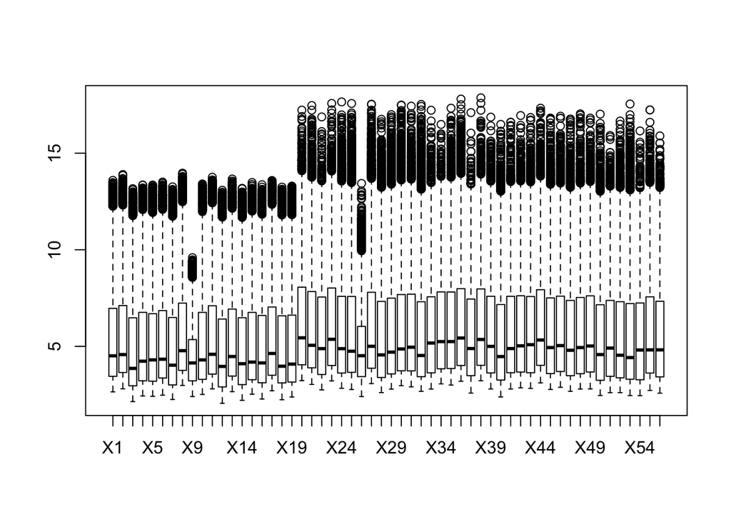

```r
boxplot(expr_data)
```

**This plot already shows some interesting data distributions:**

- There are batch effects. These kind of batch effects should be already known in advance. It is important to know how the samples were processed and annotate which samples belong to which batch.
- There are two samples that have a much lower overall gene expression, perhaps something went wrong with them.
- Overall all most of the samples have a similar distribution with slighly different means.

## The weird samples

Because normalization takes into account data from all the samples it is important to make sure that all the samples are actually good. At first glance there seems to be two bad samples. Therefore, we have to make a decision on what to do with them:

- We keep them.
- We trash them.

**What can we do to explore a bit better these samples?**

We can for example look at the amount of missing values, do they just have overall low expression of many genes or is it just that they are not measured at all.

```r
apply(expr_data, 2, function(x) sum(is.na(x)))
```

```
##    X1    X2    X3    X4    X5    X6    X7    X8    X9   X10   X11   X12   X13
##    27    26    41    25    32    30    24    32 14462    36    26    33    23
##   X14   X15   X16   X17   X18   X19   X20   X21   X22   X23   X24   X25   X26
##    29    23    30    24    26    27    28    32    35    17    29    17 13151
##   X27   X28   X29   X30   X31   X32   X33   X34   X35   X36   X37   X38   X39
##    33    21    38    25    31    21    32    23    24    19    35    17    39
##   X40   X41   X42   X43   X44   X45   X46   X47   X48   X49   X50   X51   X52
##    31    23    34    28    30    26    23    24    27    30    29    27    25
##   X53   X54   X55   X56
##    19    18    24    23
```

```r
bad_samples <- which(apply(expr_data, 2, function(x) sum(is.na(x))) > 10000)

expr_data <- expr_data[,-bad_samples]
sample_data <- sample_data[-bad_samples,]
```

We can check back at the boxplot to see if we have removed the correct ones.

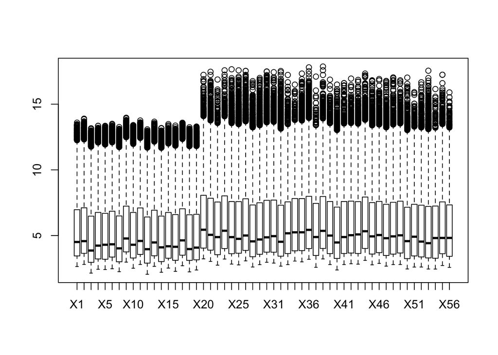

```r
boxplot(expr_data)
```

## Normalization approaches

Now we can actually normalize the data. There are several methods to do so, some more correct than others depending on the experiment design and the data type. The important concept here is that we want to make the measurements of genes comparable between samples.

For example, if geneA has an expression of 2 in sampleA and an expression of 4 in sampleB; we want to be able to say that sampleB has double the expression because it is real and not because sampleB had double the input of mRNA in the microarray.

And finally, normalization implies that we have some assumptions about the data and the experiment. Different normalization approaches imply different assumptions, and these can help us decide which method fits best for our experiment.

**What would be some fair assumptions about this experiment:**

- All the samples should have a comparable total amount of mRNA.
- All the samples should have similar distributions.

With these assumptions mean substraction, median subsetraction or quantiles normalization would work. Furthermore, it is quite established that for microarray data quantiles normalization works well. Nevertheless we can explore what would these normalizations do to our data distributions.

### Mean substraction

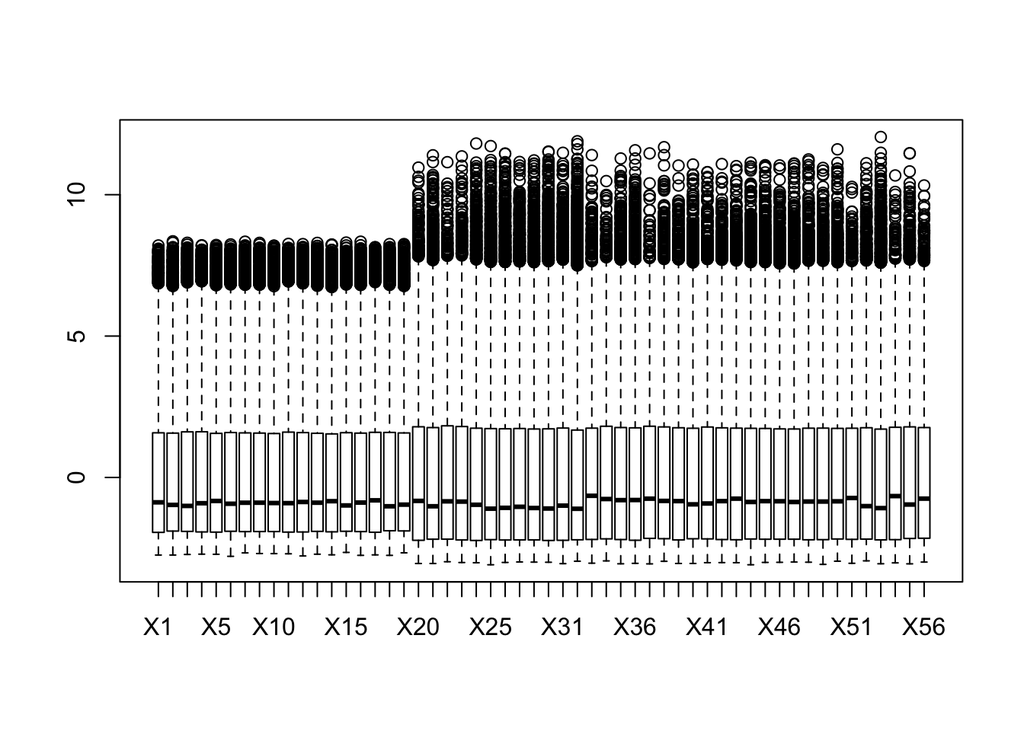

```r
sample_mean <- apply(expr_data, 2, mean, na.rm = T)
boxplot(sweep(x = expr_data, MARGIN = 2, STATS = sample_mean, FUN = '-'))
```

### Median substraction

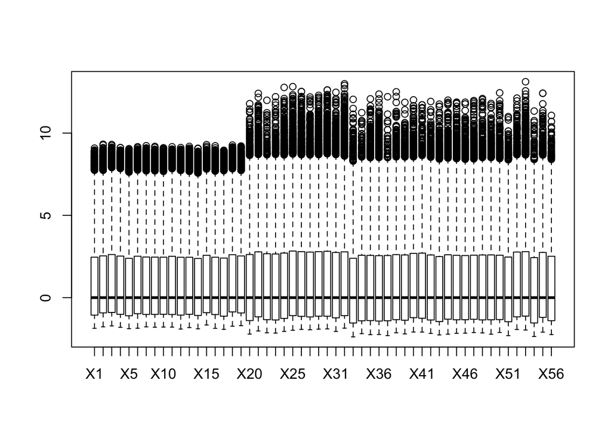

```r
sample_median <- apply(expr_data, 2, median, na.rm = T)
boxplot(sweep(x = expr_data, MARGIN = 2, STATS = sample_median, FUN = '-'))
```

### Quantiles normalization

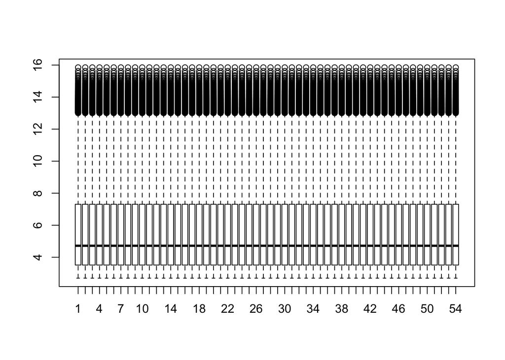

```r
boxplot(preprocessCore::normalize.quantiles(as.matrix(expr_data)))
```

```r
norm_data <- preprocessCore::normalize.quantiles(as.matrix(expr_data))
```

## Questions

- Let’s say you have done a proteomics pull down experiment on your favourite protein to see which are their binding partners. On one condition you have the WT protein; but in the other you deleted a piece of the protein genetically, and you expect that a significant portion of binding partners will not be able to bind now. How would you normalize such data?

# Batch effect removal

Batch effects are changes in the biological data that come from external factors. Different personnel performed the experiment, different machines, different days, different reagents… These are important to correct, since they can have an important effect on the data, and lead us to the wrong conclusions. For this reason it is important to check if we see any of these effects on the data. But even more important, is to know if we should expect these effects since we have designed and performed the experiment. And even if we have not done the experiment personally, we should know how it has been done.

In the first boxplots that we made, we saw that there is some batch effect going on. We also know which are the samples that have been processed in the same batch from the `sample_data` data.frame.

After we have normalized the data, it seems like the batch effect is gone. But is it really gone? Other approaches to check for batch effects are unsupervised clustering and dimensionality reduction. We will not go into detail about explaining these since they are not the objective of this notebook. They are actually explained in depth in the PCA and Clustering notebook.

## Checking by PCA

We can do a quick [Principle Components Analysis](https://en.wikipedia.org/wiki/Principal_component_analysis) (PCA) to see how the samples cluster together (similar samples should be together).

**What do you expect to see in the PCA?**

- Samples from the same CMS should cluster together.
- Triplicates witin the CMS cluster should be closer togher.

We will do a PCA and plot the socres of each sample and color them by CMS.

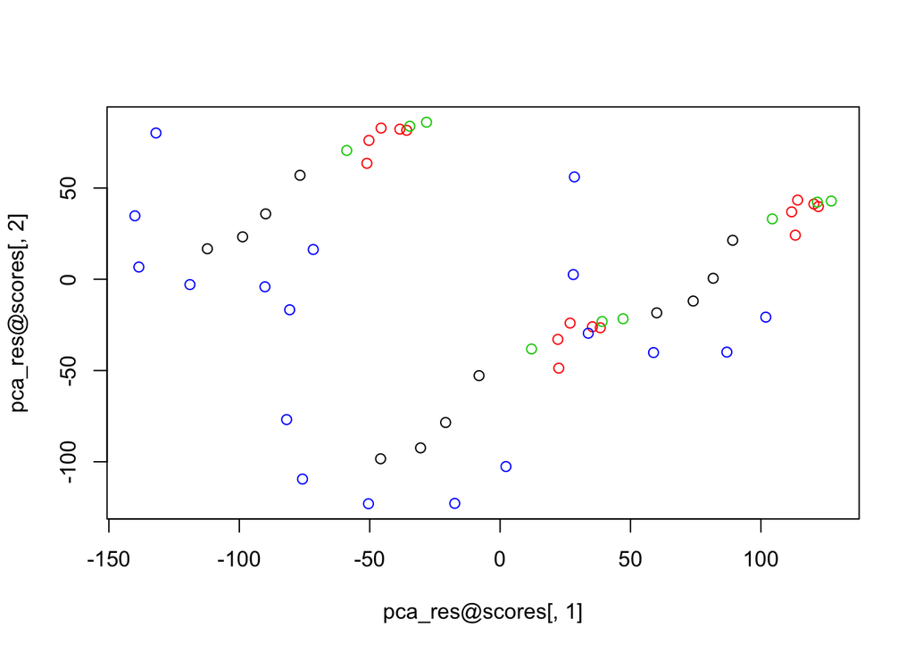

```r
pca_res <- pca(t(norm_data))
plot(pca_res@scores[,1], pca_res@scores[,2], col = sample_data$CMS)
```

And the same plot colored by batch.

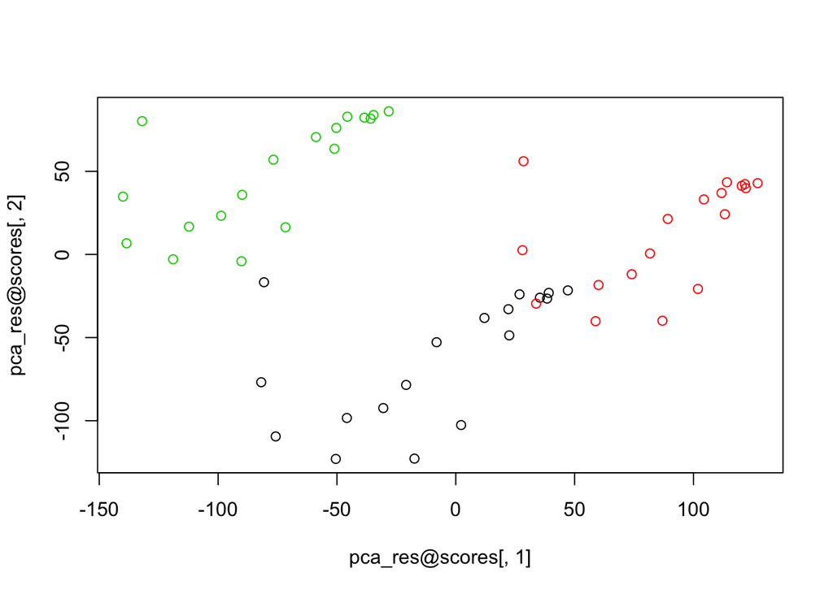

```r
plot(pca_res@scores[,1], pca_res@scores[,2], col = sample_data$batch)
```

**What do these PCA plots show?**

- There is still a clear batch effect since the samples are clustered by batch.

## Checking by distance matrix

We can also calculate what is the distance between all the samples to see which ones are most similar and which are most different.

```r
distance_matrix <- as.matrix(dist(t(norm_data), upper = TRUE, diag = TRUE))
```

```r
cms_colors <- c('red', 'blue', 'green', 'black')
batch_colors <- c('red', 'blue', 'green')
cms_colors_col <- cms_colors[sample_data$CMS]
batch_colors_col <- cms_colors[sample_data$batch]
```

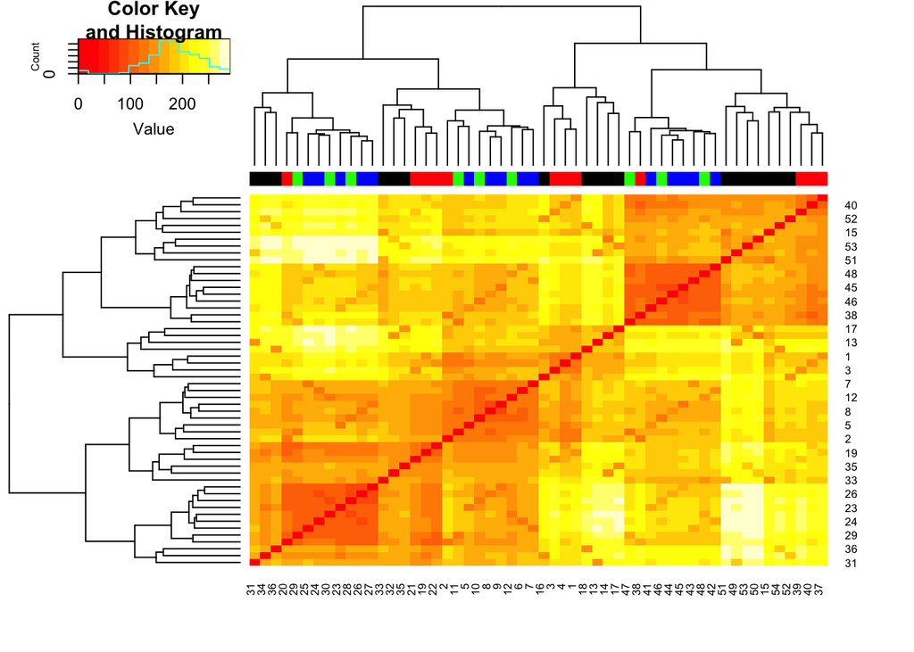

```r
heatmap.2(x = distance_matrix,
          trace = 'none',
          ColSideColors = cms_colors_col)
```

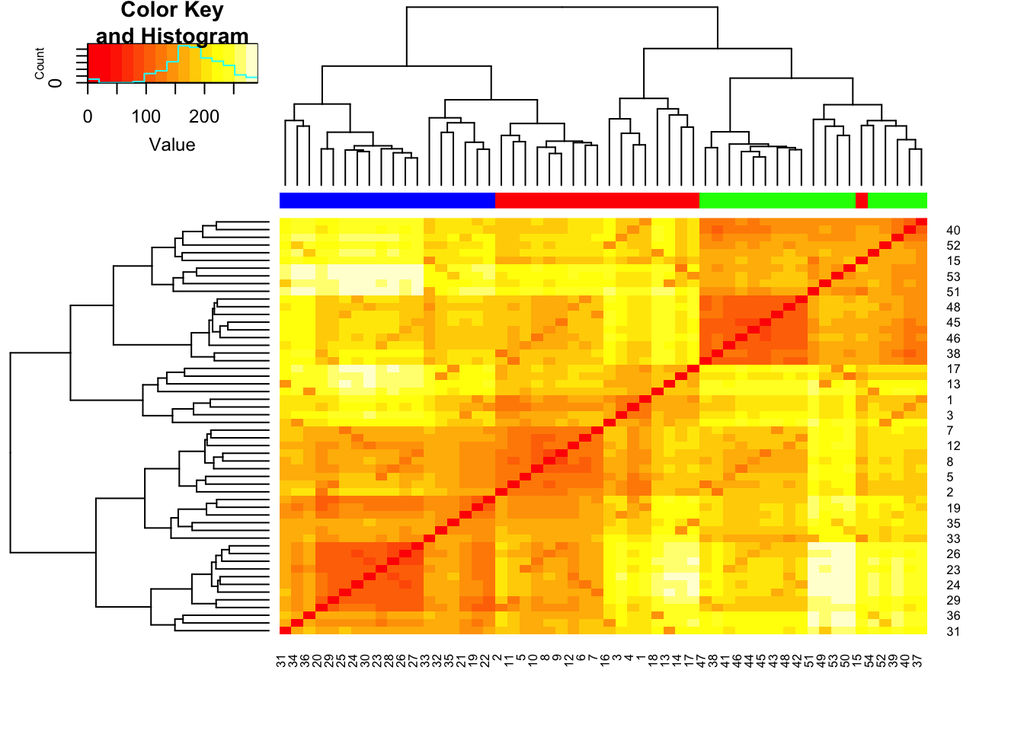

```r
heatmap.2(x = distance_matrix,
          trace = 'none',
          ColSideColors = batch_colors_col)
```

**What do these heatmaps show?**

- There is still a clear batch effect since the samples are clustered by batch.

## Correcting the batch effect

To correct the batch effect several methods have been implemented. For microarray data particularly, the [ComBat](https://academic.oup.com/biostatistics/article/8/1/118/252073) method has been shown to work particularly well. But for other types of data, single-cell rna-seq data there are other methods.

Notice that batch correction is a supervised approach, meaning that we need to know *a priori* which are the different batches.

```r
batch_corr_data <- sva::ComBat(norm_data, batch = sample_data$batch)
```

```
## Found3batches
```

```
## Adjusting for0covariate(s) or covariate level(s)
```

```
## Found1471Missing Data Values
```

```
## Standardizing Data across genes
```

```
## Fitting L/S model and finding priors
```

```
## Finding parametric adjustments
```

```
## Adjusting the Data
```

Now try to explore again the batch corrected data and see what happened.

## Explore by PCA

```r
pca_res <- pca(t(batch_corr_data))
```

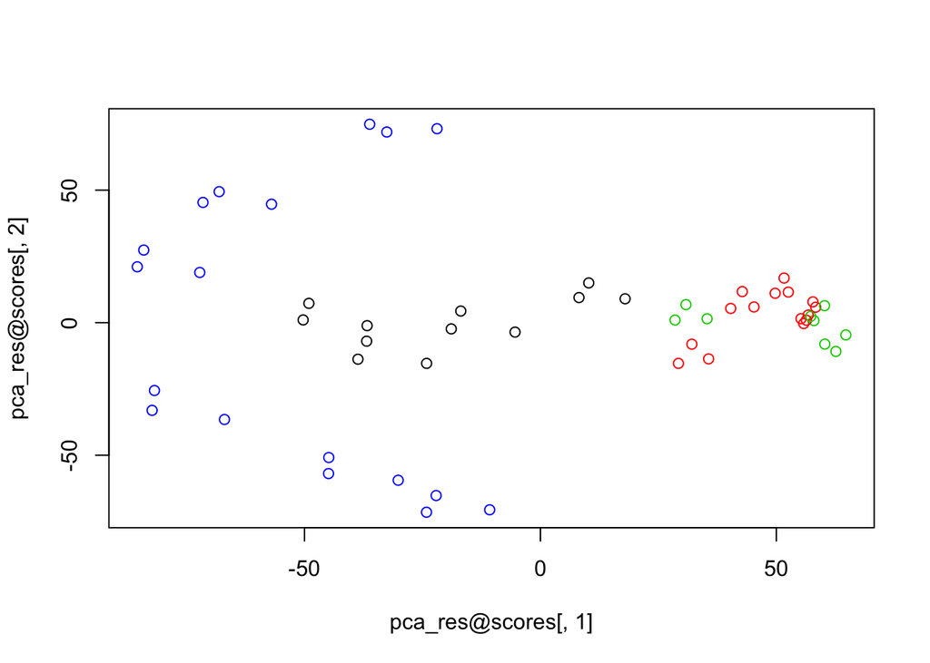

```r
plot(pca_res@scores[,1], pca_res@scores[,2], col = sample_data$CMS)
```

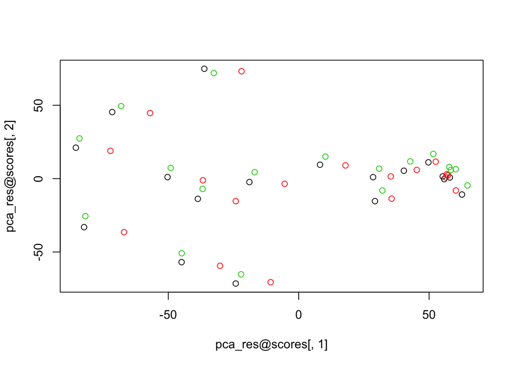

```r
plot(pca_res@scores[,1], pca_res@scores[,2], col = sample_data$batch)
```

## Explore by distance

```r
distance_matrix <- as.matrix(dist(t(batch_corr_data), upper = TRUE, diag = TRUE))
```

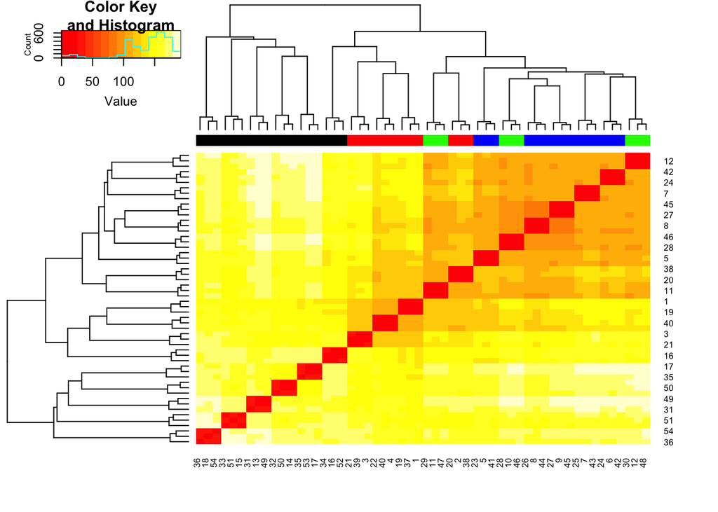

```r
heatmap.2(x = distance_matrix,
          trace = 'none',
          ColSideColors = cms_colors_col)
```

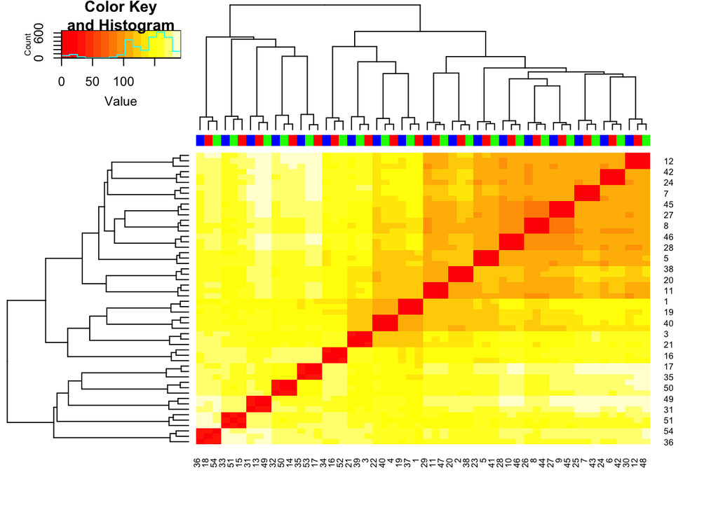

```r
heatmap.2(x = distance_matrix,
          trace = 'none',
          ColSideColors = batch_colors_col)
```

# Scaling

# Dealing with missing values

Missing values are quite common and it is important to understand why they exist in our dataset. Again, consider the type of data and the experiment design when thinking about this.

These are the different types:

- **Missing completely at random**: as the name indicates, these are values that you did not measure because of bad luck. Perhaps the probe was defective, the peptide did not fly well in the mass spec, etc.
- **Missing not at random**: these are values that are missing because of a reason. For example, the method has a limit of detection and this feature was below it. That does not mean that for example, the gene is not expressed, but rather we do not have the technology to detect its low level of expression. It could also be that the gene is actually not expressed at all because of a condition of the experiment. Or a metabolite is not detected because of the extraction method.
- **Missing because of the data processing**: these should be quite easily detectable. These are actually values that we had measured at some point and that became missing because of some processing step. For example, we tried to take the log of a negative number or calculate the mean of a set that contained a `NA` value. It is important to always check our data before and after each processing step, and make sure that everything is as we expect it to be.

There are different types of missing values, it is crucial to be able to differentiate between them whenever possible since the methods that are used to deal with each type are different. Sadly, most of the times we have a combination of these different types and it can be difficuly to confidently tell which on is which.

In R missing values are usually denoted as `NA`, but it might be different in other platforms. Consider also if `0` is a missing value or not.

Let’s explore how many missing values we have.

```r
sum(is.na(expr_data))
```

```
## [1] 1471
```

And how many non missing values.

```r
sum(!is.na(expr_data))
```

```
## [1] 1118597
```

So there are not so many missing values. Still we want to decide what to do with them. So let’s try to find out which type of missing values are they.

**How would you check which kind of missing values are they?**

- See if there are any samples with a lot/very few missing values.
- See if there are any features with a lot/very few missing values.
- See in which part of the distribution are the missing values.

Missing values per sample.

```r
apply(expr_data, 2, function(x) sum(is.na(x)))
```

```
##  X1  X2  X3  X4  X5  X6  X7  X8 X10 X11 X12 X13 X14 X15 X16 X17 X18 X19 X20 X21
##  27  26  41  25  32  30  24  32  36  26  33  23  29  23  30  24  26  27  28  32
## X22 X23 X24 X25 X27 X28 X29 X30 X31 X32 X33 X34 X35 X36 X37 X38 X39 X40 X41 X42
##  35  17  29  17  33  21  38  25  31  21  32  23  24  19  35  17  39  31  23  34
## X43 X44 X45 X46 X47 X48 X49 X50 X51 X52 X53 X54 X55 X56
##  28  30  26  23  24  27  30  29  27  25  19  18  24  23
```

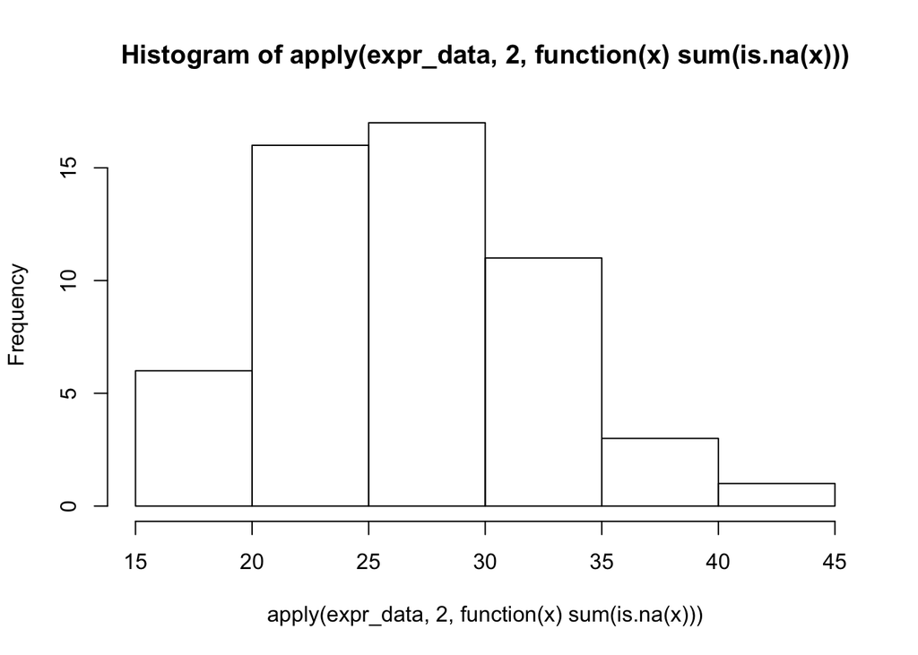

```r
hist(apply(expr_data, 2, function(x) sum(is.na(x))))
```

Missing values per gene.

```r
table(apply(expr_data, 1, function(x) sum(is.na(x))))
```

```
##
##     0     1     2    15    18    19    20
## 20211   472     8     1     6    20    24
```

Most genes have 0 missing values and then there are some have from 1 to 20.

**Notice anything strange about these values?**

Perhaps by using a heatmap we can spot what is happening.

We can use colors to tell the different subtypes apart: - Orange: CMS1 - Blue: CMS2 - Green: CMS3 - Yellow: CMS4

```r
colors <- c('CMS1' = "#E69F00", 'CMS2' = "#56B4E9",
            'CMS3' = "#009E73", 'CMS4' = "#F0E442")
colors_vec <- sapply(sample_data$CMS, function(x) {
  return(colors[as.character(x)])
})
```

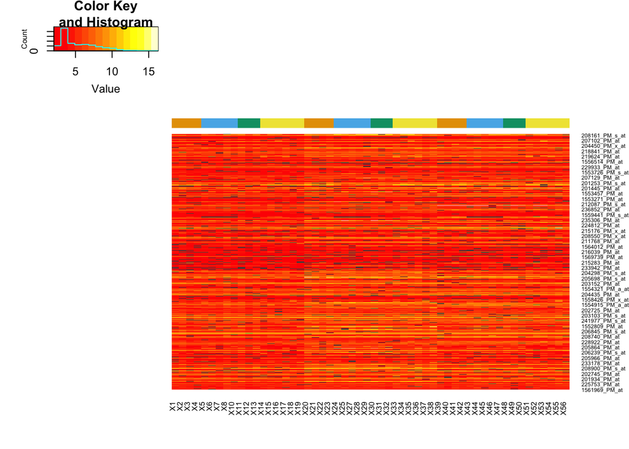

```r
genes_with_nas <- which(apply(expr_data, 1, function(x) sum(is.na(x))) > 0)
reduced_mat <- as.matrix(expr_data[genes_with_nas,])

heatmap.2(reduced_mat, Rowv = NULL, Colv = NULL,
          dendrogram = 'none', scale = 'none', trace = 'none',
          ColSideColors = colors_vec, na.color = 'grey30')
```

**What are your first impressions?**

- It looks quite random, although most of the data is at the lower end of the expression distribution.

We can focus only on the genes that have less than 3 missing values.

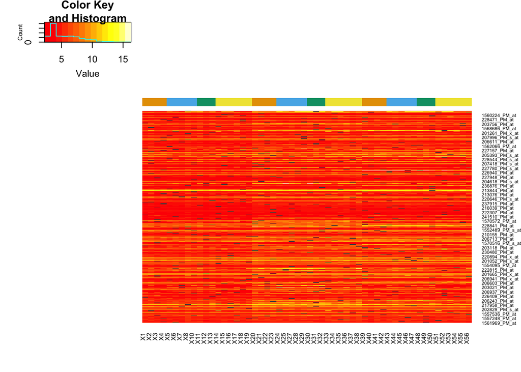

```r
genes_with_nas <- which(apply(expr_data, 1, function(x) sum(is.na(x))) > 0 &
                          apply(expr_data, 1, function(x) sum(is.na(x))) < 3)
reduced_mat <- as.matrix(expr_data[genes_with_nas,])

heatmap.2(reduced_mat, Rowv = NULL, Colv = NULL,
          dendrogram = 'none', scale = 'none', trace = 'none',
          ColSideColors = colors_vec, na.color = 'grey30')
```

**What are your first impressions?**

- Very similar to as before, this is expected since most of the genes had less than 3 missing values.

We can check the genes with more than 5 missing values

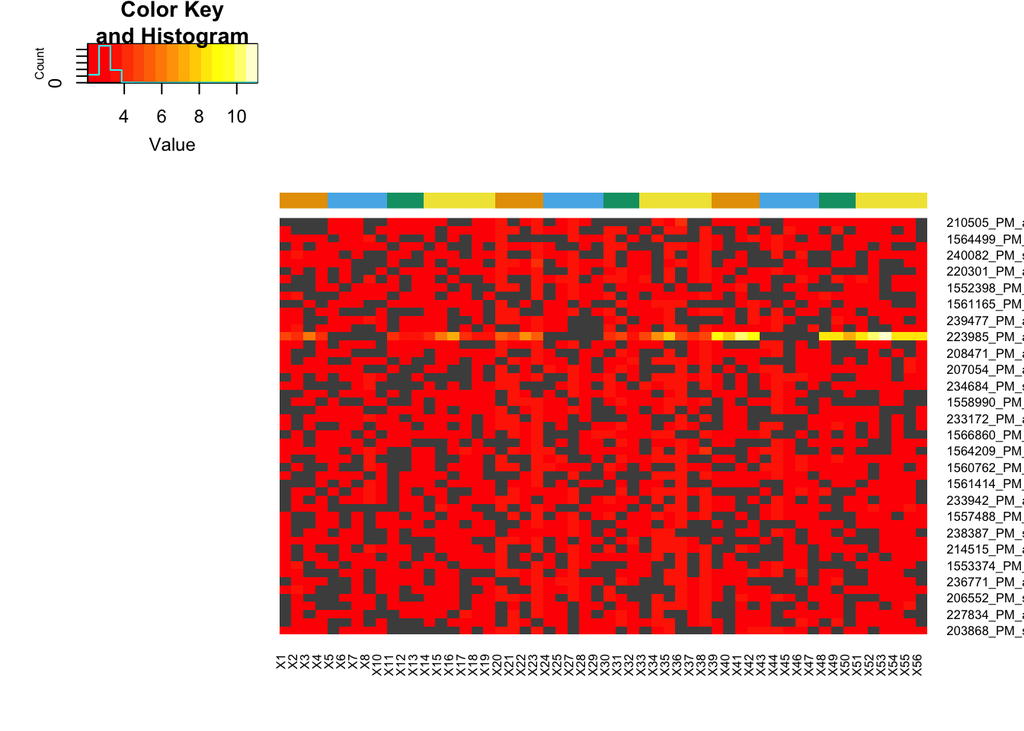

```r
genes_with_nas <- which(apply(expr_data, 1, function(x) sum(is.na(x))) > 5)
reduced_mat <- as.matrix(expr_data[genes_with_nas,])

heatmap.2(reduced_mat, Rowv = FALSE, Colv = FALSE,
          dendrogram = 'none', scale = 'none', trace = 'none',
          ColSideColors = colors_vec, na.color = 'grey30')
```

**What are your first impressions?**

- These are genes that are clear on the low end of expression. Probably missing because of the limit of detection. Besides that it would seem random.
- There is one gene that stands out! it appears that is detected with high expression in all samples but the ones in CMS2!

So far we have explored our missing values. It looks like the majority of them are random, with enfasis at missing at random but with a detection limit component. Finally there is one gene that has not at random missing values.

Now we have to decide what do we do with these missing values. Again, depending on the type of data and experiment we migth want to keep the missing values, remove them or impute them. It is important to decide whether the missingness of a value has information or not.

Some options of what we can do:

- The simple and extreme case would be to remove all genes with missing values. This is a simple method that will give you a dataset with no missing data.
- Another method would be to remove genes that have a lot of missing values but keep the ones with few missing values. The threshold is quite arbitrary.
- Another method would be to impute them, this means giving them an actual measurement. But which measurement should we give them? This option even opens more options, in which we have to decide which imputation method we want to use, some examples would be:
  - Use the average of the sample
  - Use a value close to the limit of detection
  - Impute it based on its most similar sample

**What would you do?**

Dealing with missing values is quite complex and is extremely dependent on the experiment. In this particular case our final objective is to build a predictor, a predictor needs to be robust, therefore using genes that are sometimes detected and sometimes not is not a good idea. Since most of the values seem random imputation based on the most similar sample would probably work fine. On the other hand, since there are not so many genes that actually have missing values we could also not use them.

We can also try different methods, and then see how the data looks like; specially in this case since we are adding data that will be as important as the real data we want to check that we are not creating any aberrations.

Removing missing genes.

```r
genes_to_remove <- which(apply(expr_data, 1, function(x) sum(is.na(x))) > 0)

reduced_data <- expr_data[-genes_to_remove,]
```

```r
mean_col <- apply(expr_data, 1, mean, rm.na = TRUE)
imputed_data <- expr_data
for (i in seq_len(ncol(imputed_data))) {

  col_data <- imputed_data[,i]
  col_data[is.na(col_data)] <- mean_col[i]
  imputed_data[,i] <- col_data

}
```

Setting missing values as a lower quantile value

```r
quantile(expr_data, na.rm = T)
```

```
##        0%       25%       50%       75%      100%
##  2.053516  3.555102  4.709975  7.330005 17.865068
```

```r
imputed_data <- expr_data
imputed_data[is.na(imputed_data)] <- quantile(expr_data, na.rm = T)[1]
```

## Questions

- How can you determine if a sample has too many missing values?

# Feature selection (pre-ML)

# Conclusions

In this notebook we have learned about some of the key aspects of data pre-processing, exploration and cleaning. Keep in mind, that the methods that we have applied here are particularly suited for this kind of data and experiment. It is of extreme importance to research which are the adequate methods for each type of dataset and type of experiment.

Final note, all the impurities that this dataset had where added artifitially with teaching purpouses.